# Extraordinary Least Squares

Best-Fit Lines, Statistical Control, and Uncertainty

Professor Benjamin Noble

## Regression Is About Relationships

We want to know if X causes Y. But first, we need to describe the relationship between them.

- Does Y change as X changes?
- Is the relationship positive or negative?
- How big is the relationship?
- Is the relationship real or just noise?

## Do Taller People Earn More Money?

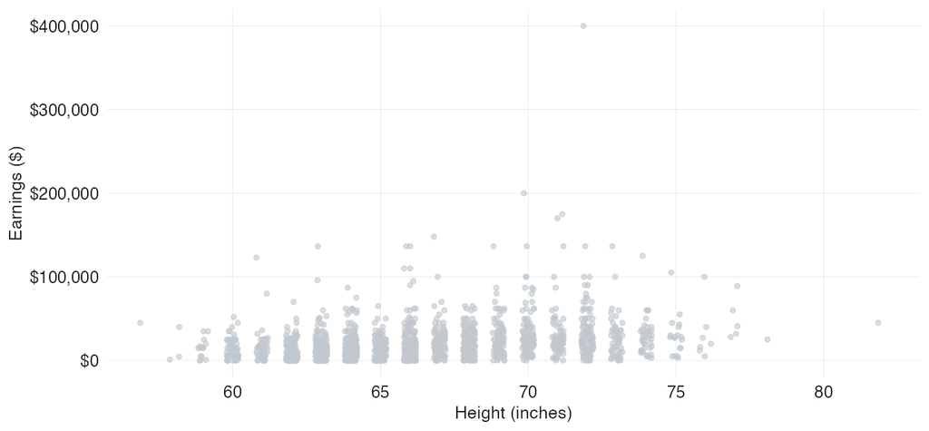

## Do Taller People Earn More Money?

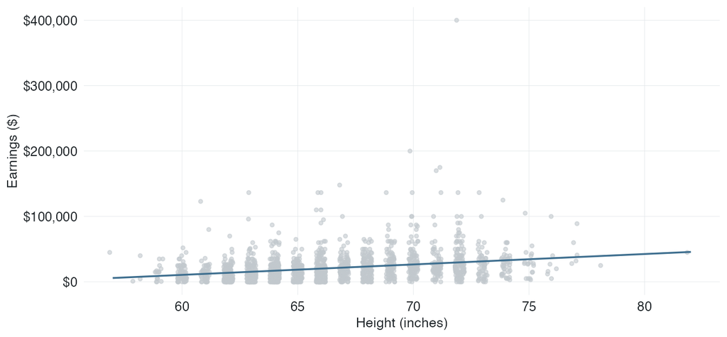

## Do Taller People Earn More Money?

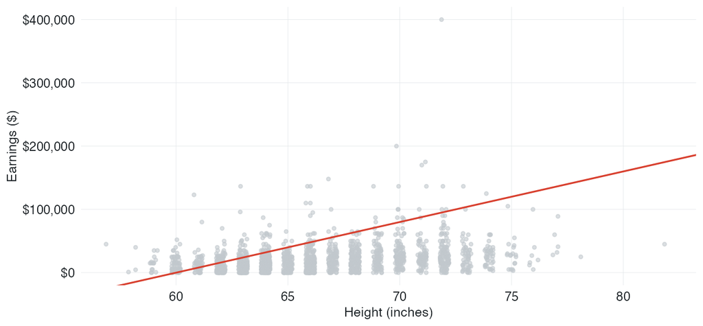

## Linear Regression

$$y = mx + b$$
$$y_i = \beta_0 + \beta_1 x_i + \epsilon_i$$

Where…

- $y_i$ is the dependent/outcome variable.
- $x_i$ is the independent/predictor/explanatory variable.
- $\beta_0$ is the intercept.
- $\beta_1$ is the slope.
- $\epsilon_i$ is the error (everything about $y$ we don’t capture with $x$).

## Modeling the Gender Gap

[output not shown]

[figure not shown]

## Reading Regression Output

`summary(lm(earnk ~ male, data = earnings))`

| Term | Estimate | Std. Error | t value | p-value |
| --- | --- | --- | --- | --- |
| (Intercept) | 15.85 | 0.64 | 24.9 | < .001 |
| male | 14.26 | 1.04 | 13.7 | < .001 |

**R-squared** 0.094

## Why We Need Regression

With a binary variable, computing averages is easy. With a continuous variable, it isn’t.

- Sex has two values → two group means, one difference.
- Height has many values → averaging at every height gets unwieldy.
- Regression uses one fitted line to approximate the averages.
- Scales to many variables at once.

## Modeling Height and Earnings

`lm(earnk ~ height, data = earnings)`

| Term | Estimate | Std. Error |
| --- | --- | --- |
| (Intercept) | -85.03 | 8.86 |
| height | 1.59 | 0.13 |

**R-squared** 0.074

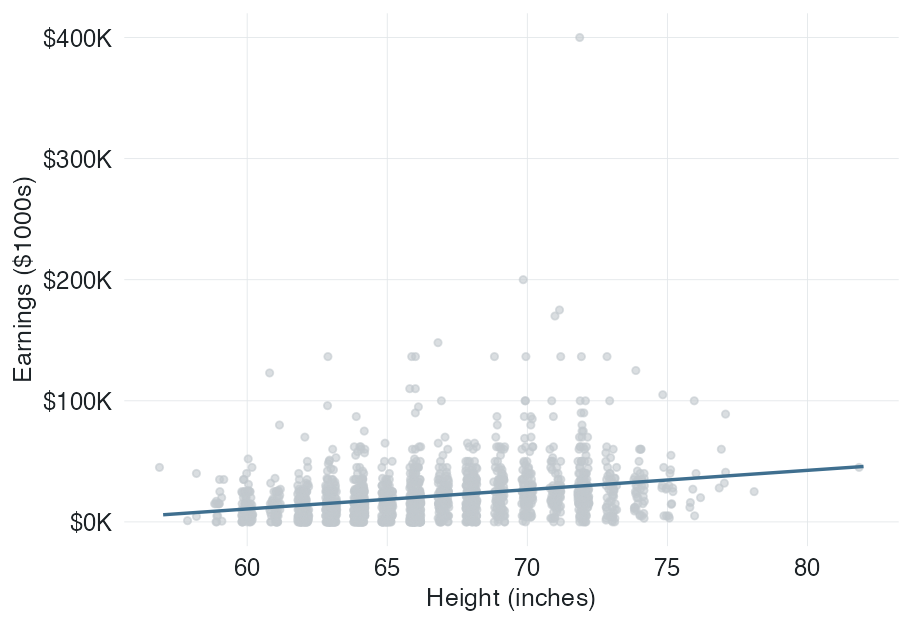

## Regression as Prediction

Plug a height into the equation to predict earnings.

- **Equation:** earnings = -85.03 + 1.59 × height
- **Plug in 60:** -85.03 + 1.59 × 60 = 10.37
- A 60-inch person is predicted to earn about **$10K**.

| Height (in) | Predicted Earnings ($1K) |
| --- | --- |
| 58 | 7.2 |
| 60 | 10.4 |
| 65 | 18.3 |
| 70 | 26.3 |
| 72 | 29.5 |

## Where Does the Line Come From?

Some lines miss the points by less than others. Which line is best?

- A **residual** is the vertical miss: $y_i - \hat{y}_i$
- Bad lines have big residuals, good lines have small ones.
- We need one number that summarizes how “bad” a line is. Choose the least bad.
- Choose $\beta_0$ and $\beta_1$ to minimize the sum of squared residuals:

$$\sum (y_i - \hat{y}_i)^2 = \sum (y_i - \beta_0 - \beta_1 x_i)^2$$

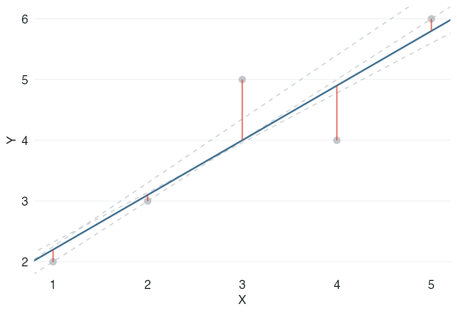

## Grid Search

Try many lines, keep the lowest sum of squared residuals.

- Build a grid of candidate intercepts ($\beta_0$) and slopes ($\beta_1$).
- Compute $\sum (y_i - \beta_0 - \beta_1 x_i)^2$ at every combination. For example, `sum((earnings - b0 - b1 * male)^2)`.
- Keep the pair with the smallest SSR, the cool end of the heatmap.

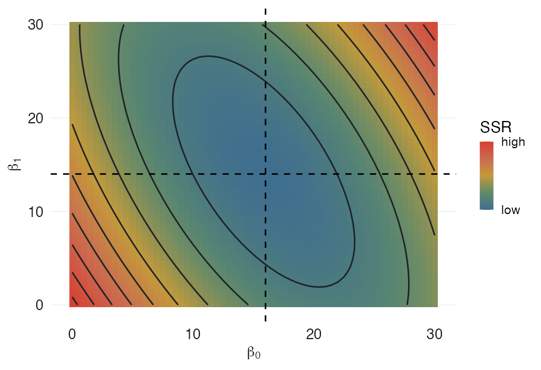

## The Conditional Expectation Function

$E[Y \mid X = x]$, the average $y$ at a chosen value of $x$.

- With a binary predictor, there are two conditional means.
- They match the regression line.
- That isn’t an accident: for a single binary predictor, regression is the conditional mean.

| Condition | Mean earnings ($1K) |
| --- | --- |
| male = 0 | 15.8 |
| male = 1 | 30.1 |

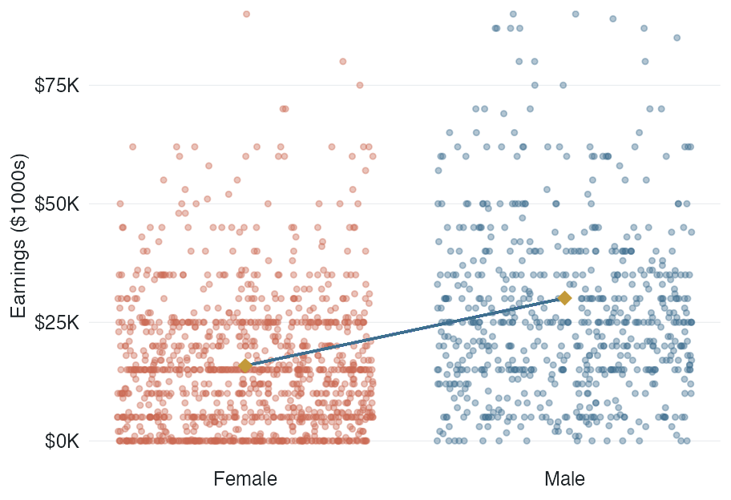

## The CEF and Regression for Height

- The dashed line (with triangle markers) is the the CEF: average earnings at each height.
- The solid line is the regression of earnings on height.
- Regression is the *best linear approximation* of the CEF.

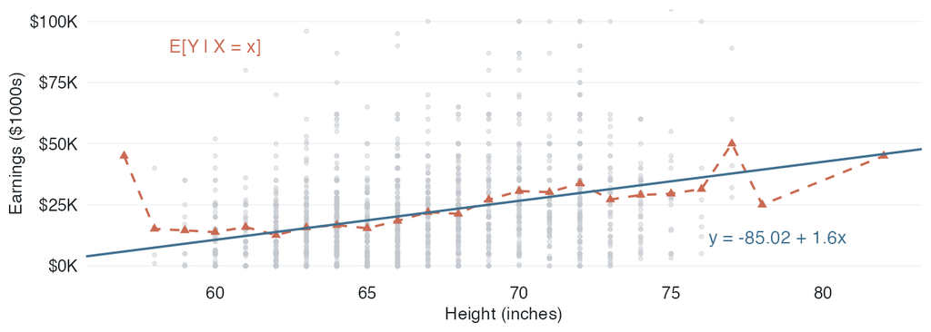

## But Wait: Does Height *Really* Matter?

- Men are taller than women on average.
- Men also earn more, on average.
- So the height coefficient may be partly a disguised gender difference.
- Regression lets us ask whether height still matters after holding sex constant.

## Controlling for Sex

Adding sex to the model shrinks the height coefficient from 1.60 to 0.65.

`lm(earnk ~ male + height, data = earnings)`

| Term | Estimate | Std. Error | t value | p-value |
| --- | --- | --- | --- | --- |
| (Intercept) | -25.87 | 11.96 | -2.2 | 0.031 |
| male | 10.63 | 1.47 | 7.2 | < .001 |
| height | 0.65 | 0.19 | 3.5 | < .001 |

**R-squared** 0.1

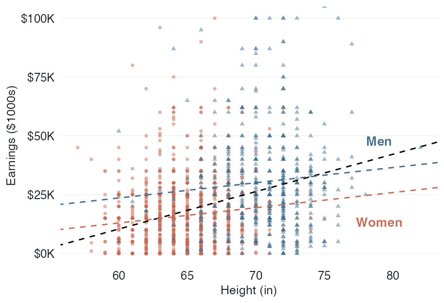

## Another Visualization: A Plane Through the Data

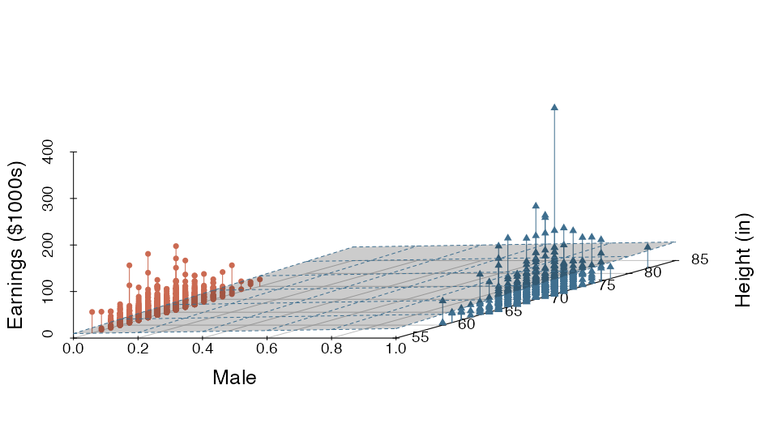

## Danger: Extrapolating Beyond the Data

Regression will make predictions even where there’s no data.

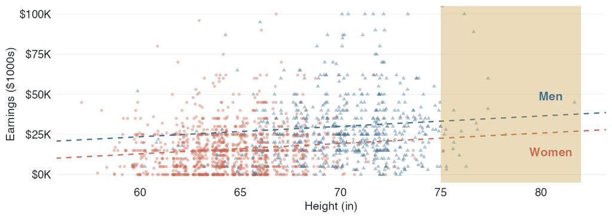

## Interactions

An interaction lets the height slope differ for women and men.

`lm(earnk ~ male * height, data = earnings)`

| Term | Estimate | Std. Error |
| --- | --- | --- |
| (Intercept) | -8.49 | 15.87 |
| male | -31.51 | 25.33 |
| height | 0.38 | 0.25 |
| male:height | 0.62 | 0.37 |

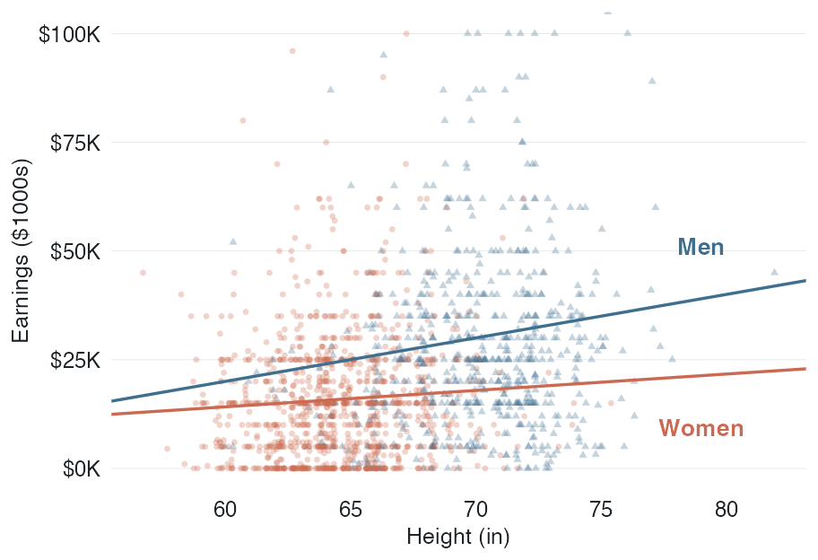

## Adding Additional Predictors

- Each coefficient compares people who match on every other variable in the model.
  - The height coef now holds sex, age, education, and race constant.
- More controls means fewer real matches in the data backing each comparison.

| Term | Estimate | Std. Error | p-value |
| --- | --- | --- | --- |
| (Intercept) | -60.74 | 11.88 | < .001 |
| male | 11.40 | 1.39 | < .001 |
| height | 0.48 | 0.18 | 0.007 |
| education | 2.70 | 0.19 | < .001 |
| age | 0.19 | 0.03 | < .001 |
| ethnicityHispanic | -0.93 | 2.50 | 0.71 |
| ethnicityOther | 1.22 | 3.61 | 0.736 |
| ethnicityWhite | 2.22 | 1.60 | 0.166 |

## How Certain Are We About These Estimates?

- We estimated people earn about **$1.6K per inch**.
- But…another sample of 1,800 people could give a slightly different slope.
- That sample-to-sample movement is **sampling uncertainty**.
- Standard errors tell us how much the estimate would move across samples.

## Sampling Variation (The Bootstrap)

- Draw 1,800 people from the data, **with replacement**.
- Refit regression model on new data and save the slope.
- Repeat 1,000 times.
- The standard deviation of the slopes approximates the standard error.

[figure not shown]

## Where Standard Errors Come From

The standard error captures how much the slope shifts across repeated samples.

$$se_{\hat{\beta}_1} = \sqrt{\frac{\sum \hat \epsilon_i^2}{(n - k)\sum (x_i - \bar{x})^2}}$$

- **Numerator** (squared residuals): a worse-fitting line means a bigger SE.
- **Denominator**: bigger $n$ or more spread in $x$ means a smaller SE.

## What About p-values and Statistical Significance?

- Probability of observing a test statistic as extreme as observed under the assumption that the true coefficient is 0.
- Divide the coefficient by the SE. If the coefficient is at least twice its standard error, the estimate is “hard to explain” as noise.
- The “2” comes from the normal distribution, where two standard deviations capture 95% of the data.

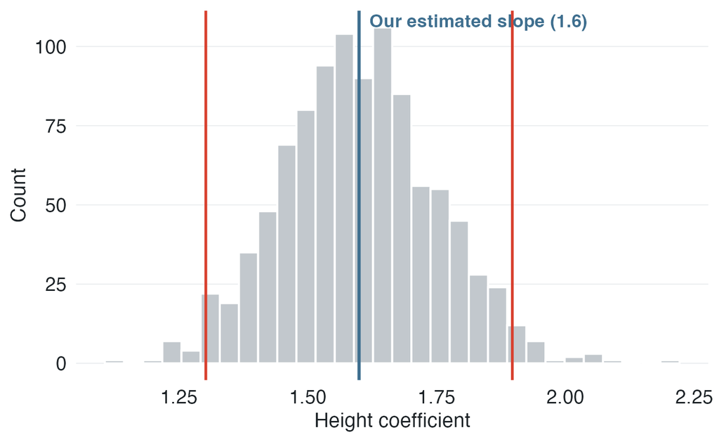

## Why Regression?

Regression turns messy data into interpretable numbers.

- A cloud of points becomes a line.
- A line becomes a coefficient.
- A coefficient becomes an interpretation.
- Uncertainty tells us how much to trust it.